# Map compositions

```r
library(geopt)
library(ggplot2)
```

The Açores are about 1,500 km west of the mainland, and Madeira about 1,000 km to the south-west. Drawn in their true positions, most of a map of Portugal would be empty ocean. So geopt *composes* the map: it moves the islands next to the mainland, as insets, and draws frames around them to show they’ve been moved. This guide shows how to control that composition, and how to draw the result with different plotting libraries.

## Default map

`get_map()` returns the composed map. Called with no arguments, it returns municipalities, with the islands moved next to the mainland and framed:

```r
m <- get_map()
```

The result is a standard `sf` object in WGS84 (EPSG:4326). The frames are extra rows in it: the `geopt_type` column is `"boundary"` for the regions and `"frame"` for the frames. On the frames, `geopt_label` holds the frame’s name and `geopt_frame_level` says what it surrounds: 1 for a whole archipelago, 2 for a group of islands, and 3 for a single island.

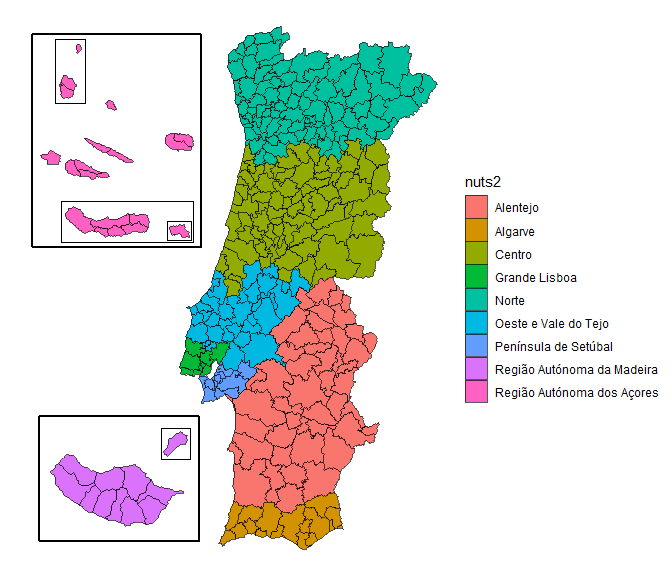

```r
boundaries <- m[m$geopt_type == "boundary", ]
frames <- m[m$geopt_type == "frame", ]

ggplot() +
  geom_sf(data = boundaries, aes(fill = nuts2)) +
  geom_sf(data = frames, aes(linewidth = factor(geopt_frame_level)), fill = NA) +
  scale_linewidth_manual(values = c(0.8, 0.4, 0.2)) +
  guides(linewidth = "none") +
  theme_void()
```

## Administrative levels

The `level` argument sets which units to draw: `"freguesia"`, `"municipio"` (the default), `"distrito"`, `"nuts1"`, `"nuts2"` or `"nuts3"`, or one of the health geographies, `"uls"`, `"reg_saude"`, `"aces"`, `"uls_municipio"` and `"aces_municipio"` (see `vignette("health-geographies")`). Every level is built by merging the same simplified freguesias, so borders line up exactly when two levels are drawn on top of each other.

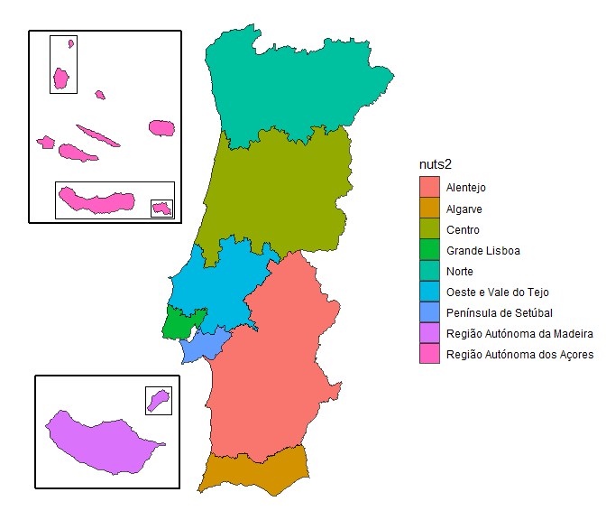

```r
m_nuts2 <- get_map("nuts2")
boundaries <- m_nuts2[m_nuts2$geopt_type == "boundary", ]
frames <- m_nuts2[m_nuts2$geopt_type == "frame", ]

ggplot() +
  geom_sf(data = boundaries, aes(fill = nuts2)) +
  geom_sf(data = frames, aes(linewidth = factor(geopt_frame_level)), fill = NA) +
  scale_linewidth_manual(values = c(0.8, 0.4, 0.2)) +
  guides(linewidth = "none") +
  theme_void()
```

## How the islands are shown

The `islands` argument sets how the Açores and Madeira appear. It takes one of these values:

| Value | Açores | Madeira |
| --- | --- | --- |
| `"compact"` (default) | four insets: the western group, the central group, São Miguel, and Santa Maria | Porto Santo in its own small inset, moved next to Madeira |
| `"groups"` | the three official groups: Ocidental, Central and Oriental | the same as `"compact"` |
| `"box"` | a labelled rectangle | a labelled rectangle |
| `"in_place"` | where they really are | where they really are |
| `"none"` | left out | left out |

For anything else, such as a different setting for each archipelago, or no frames, pass a layout made with `island_layout()`. A string is a shortcut: `islands = "none"` is the same as `islands = island_layout("none")`.

### Leaving the islands out

To show only the mainland:

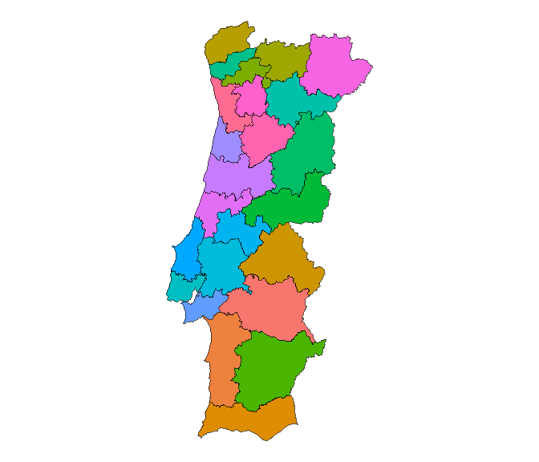

```r
m <- get_map("nuts3", islands = "none")
ggplot(m) +
  geom_sf(aes(fill = nuts3)) +
  guides(fill = "none") +
  theme_void()
```

To leave out one archipelago, set it to `"none"` in `island_layout()`, using `raa` for the Açores and `ram` for Madeira:

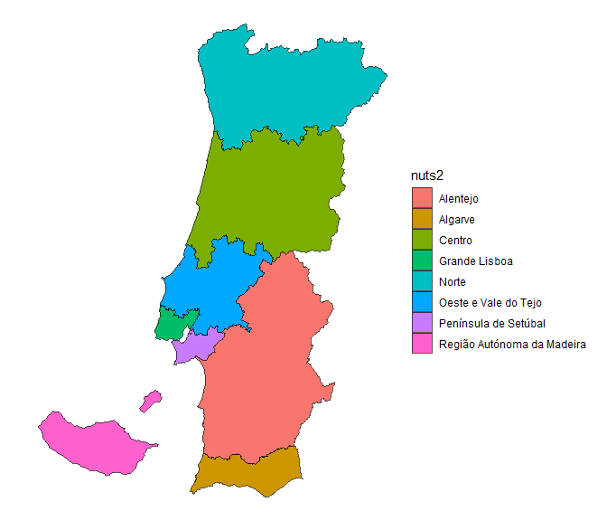

```r
m <- get_map("nuts2", islands = island_layout(raa = "none"))
ggplot(m[m$geopt_type == "boundary", ]) +
  geom_sf(aes(fill = nuts2)) +
  theme_void()
```

When data is joined with `data` and `by`, rows for a left-out archipelago are dropped quietly: they matched, they just aren’t on the map.

### Island groups

`"compact"` arranges the islands to take the least room, so Santa Maria gets an inset of its own. `"groups"` draws the Açores in their three official groups instead, and `ram = "whole"` puts Madeira and Porto Santo in a single inset, at their true distance apart:

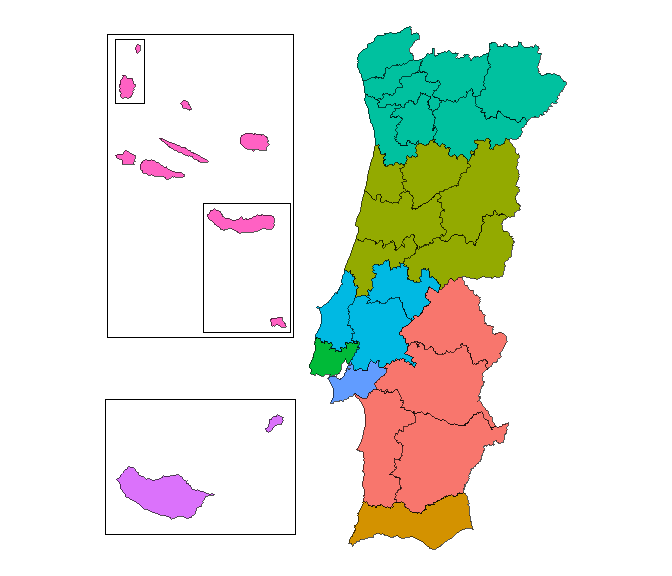

```r
m <- get_map("nuts3", islands = island_layout(raa = "groups", ram = "whole"))
boundaries <- m[m$geopt_type == "boundary", ]
frames <- m[m$geopt_type == "frame", ]

ggplot() +
  geom_sf(data = boundaries, aes(fill = nuts2)) +
  geom_sf(data = frames, fill = NA, linewidth = 0.5) +
  guides(fill = "none") +
  theme_void()
```

There is no `"whole"` for the Açores. The archipelago is wider than all of mainland Portugal, so in a single inset that fits next to the mainland its smaller islands would be too small to read. To show all of the Açores as they really are, map them on their own (see Maps of one region).

### Frames around the islands

The frames are added by default. Map `geopt_frame_level` to line width so the frame around a whole archipelago is thicker than the frames around single islands, as in the maps above. To leave the frames out, use `frames = FALSE`:

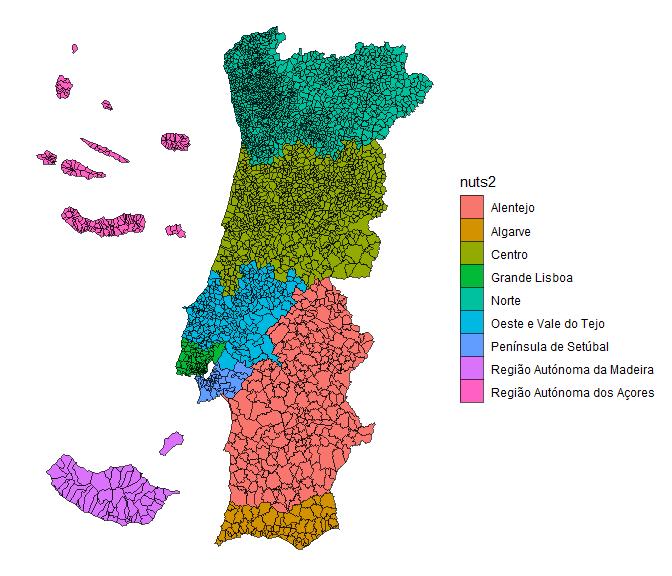

```r
m <- get_map("freguesia", islands = island_layout(frames = FALSE))
ggplot(m) +
  geom_sf(aes(fill = nuts2), linewidth = 0.05) +
  theme_void()
```

### Islands as rectangles

`"box"` replaces each archipelago with a labelled rectangle, which keeps the map compact when only one value per archipelago is needed. It only works at levels where each archipelago is a single region: `"nuts1"`, `"nuts2"`, `"nuts3"` and `"reg_saude"`. At finer levels each archipelago has several regions, and `"box"` stops with an error rather than draw a stack of rectangles that no longer reads as a map.

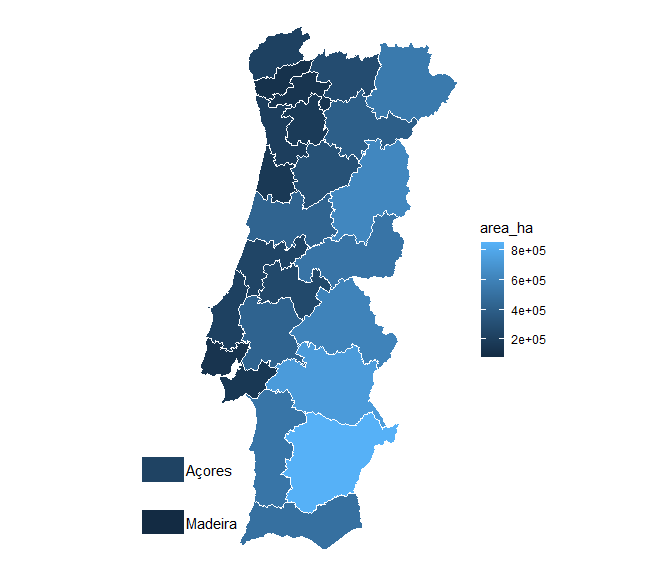

```r
m <- get_map("nuts3", islands = "box")

ggplot() +
  geom_sf(data = m, aes(fill = area_ha), color = "white") +
  geom_sf_text(
    data = m[!is.na(m$geopt_label), ],
    aes(label = geopt_label),
    nudge_x = 0.3,
    hjust = 0,
    size = 4
  ) +
  theme_void()
```

By default the rectangles go at the bottom left of the mainland. Use `box_position = "top_left"`, or give the longitude and latitude of the bottom-left corner of the stack as `c(x, y)`:

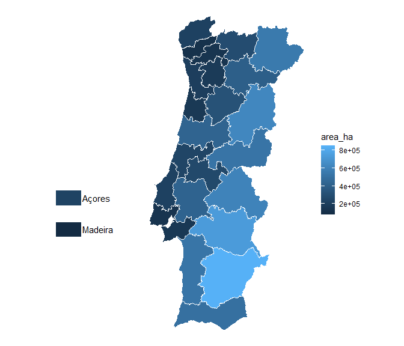

```r
m <- get_map("nuts3", islands = island_layout("box", box_position = c(-11.5, 38.5)))

ggplot() +
  geom_sf(data = m, aes(fill = area_ha), color = "white") +
  geom_sf_text(
    data = m[!is.na(m$geopt_label), ],
    aes(label = geopt_label),
    nudge_x = 0.3,
    hjust = 0,
    size = 4
  ) +
  theme_void()
```

## Moving and resizing the islands

`island_layout()` returns a list that can be changed before passing it on. Each archipelago drawn as insets has an `anchor`, the longitude and latitude its insets are placed around, a `label` for its frame, and `groups`, one entry per inset, each with its own `offset` from the anchor and `scale`. Printing a layout shows what it does:

```r
lay <- island_layout()
lay
```

```
#> <island layout>
#>   raa (Açores):  compact   4 insets: ocidental, central, s_miguel, s_maria
#>   ram (Madeira):  compact   2 insets: madeira, porto_santo
#>   frames:         yes
```

For example, to move the Açores half a degree further west, draw Madeira a little smaller, and label the Açores in English:

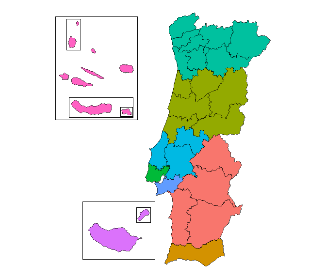

```r
lay$raa$anchor <- lay$raa$anchor + c(-0.5, 0)
lay$ram$groups$madeira$scale <- 2.5
lay$raa$label <- "Azores"

m <- get_map("nuts3", islands = lay)
frames <- m[m$geopt_type == "frame", ]

ggplot() +
  geom_sf(data = m[m$geopt_type == "boundary", ], aes(fill = nuts2)) +
  geom_sf(data = frames, fill = NA, linewidth = 0.4) +
  guides(fill = "none") +
  theme_void()
```

```r
frames$geopt_label
```

```
#> [1] "Azores"          "Grupo Oriental"  "Grupo Ocidental" "Santa Maria"
#> [5] "Madeira"         "Porto Santo"
```

Print `lay$raa` to see every setting, and `?island_layout` for what each one does. If a change breaks the layout, `get_map()` says which setting is wrong.

## Maps of one region

Every row of `get_map()` keeps its codes and names, so a map of one region is the whole map, filtered. For an area of the mainland, filter the map as it is:

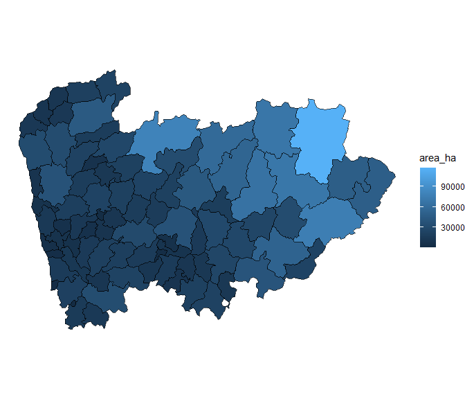

```r
m <- get_map("municipio")
norte <- m[m$nuts2_cod %in% "PT11", ]

ggplot(norte) +
  geom_sf(aes(fill = area_ha)) +
  theme_void()
```

Using `%in%` rather than `==` matters here: the frames have no region codes, and `%in%` drops them where `==` would add empty rows.

For an archipelago, use `islands = "in_place"` first. Otherwise the islands have already been moved and enlarged into their insets by the time the map is filtered. With `"in_place"` they keep their true position, and no frames are drawn:

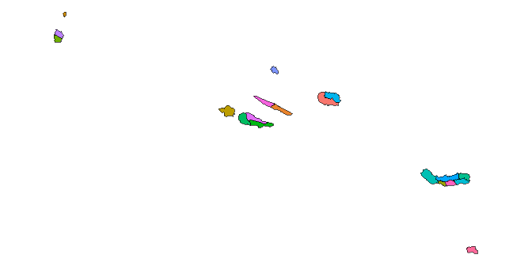

```r
m <- get_map("municipio", islands = "in_place")
acores <- m[m$nuts2_cod %in% "PT20", ]

ggplot(acores) +
  geom_sf(aes(fill = municipio)) +
  guides(fill = "none") +
  theme_void()
```

The filtered map is still a `get_map()` map, so `plot_pt()` draws it too, and data joined with `data` and `by` comes along. Health maps have no NUTS 2 or NUTS 3 codes, because their units don’t nest in those regions; filter them by `nuts1_cod` (`"PT2"` for the Açores, `"PT3"` for Madeira).

## Quick plots

`plot_pt()` draws a map in one line. It builds the map (or takes one built with `get_map()`), colours it by a column, and draws the frames and island labels. It returns an ordinary object of the plotting library it used: a ggplot to extend with `+`, or an echarts4r widget to pipe into `e_*()` functions. It takes the same `islands` argument as `get_map()`.

```
#> get_map: 303 boundaries have no data row (NA fill).
```

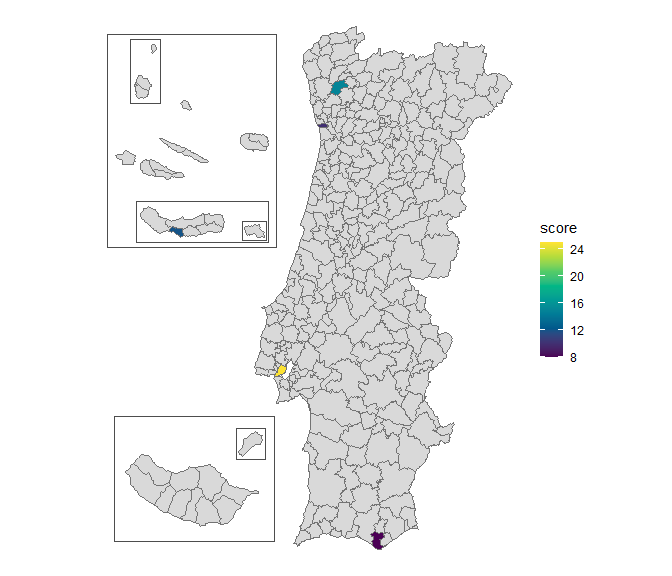

```r
df <- data.frame(
  concelho = c("Porto", "Lisboa", "Braga", "Faro", "Lagoa (Açores)"),
  score = c(10, 25, 15, 8, 12)
)

plot_pt(df, value = "score", by = c(municipio = "concelho"))
```

Build the map once and draw it with different plotting libraries, for example when the same map goes into a report (ggplot) and a dashboard (echarts):

```r
m <- get_map("nuts3", islands = "box")

plot_pt(m, value = "area_ha")                        # ggplot
plot_pt(m, value = "area_ha", renderer = "echarts")  # interactive widget
```

The echarts version links values to regions by official code, not by name, so a value can’t end up on the wrong one of two places with the same name. Tooltips still show the names.

`plot_pt()` only sets the colours (`palette`, `na_color`) and the `legend`. Everything else is styled the usual way for each library:

```r
plot_pt(df, value = "score", by = c(municipio = "concelho")) +
  labs(title = "My indicator") +
  theme(legend.position = "bottom")

plot_pt(m, value = "area_ha", renderer = "echarts") |>
  echarts4r::e_title("Area by NUTS3")
```

## Mapping libraries

The sf objects returned by `get_map()` work with any spatial plotting library; `plot_pt()` is a shortcut, not a requirement. Below are examples with the libraries geopt has been tested with.

### ggplot2

ggplot2 with `geom_sf()` is the most straightforward option for static maps:

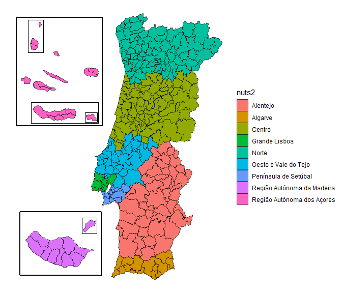

```r
m <- get_map("municipio")
boundaries <- m[m$geopt_type == "boundary", ]
frames <- m[m$geopt_type == "frame", ]

ggplot() +
  geom_sf(data = boundaries, aes(fill = nuts2)) +
  geom_sf(data = frames, aes(linewidth = factor(geopt_frame_level)), fill = NA) +
  scale_linewidth_manual(values = c(0.8, 0.4, 0.2)) +
  guides(linewidth = "none") +
  theme_void()
```

### tmap

tmap supports both static (`"plot"`) and interactive (`"view"`) modes. The same code produces a static plot or a leaflet widget depending on the active mode:

```r
library(tmap)

m <- get_map("nuts2")
boundaries <- m[m$geopt_type == "boundary", ]
frames <- m[m$geopt_type == "frame", ]

# Static mode
tmap_mode("plot")
```

```
#> ℹ tmap modes "plot" - "view"
#> ℹ toggle with `tmap::ttm()`
```

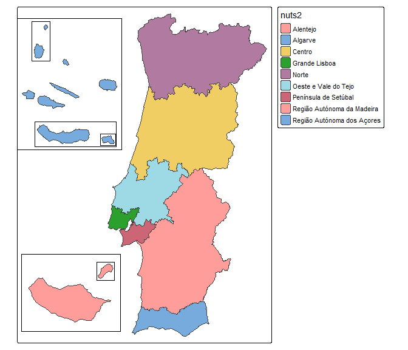

```r
tm_shape(boundaries) +
  tm_polygons(fill = "nuts2") +
  tm_shape(frames) +
  tm_lines(
    lwd = "geopt_frame_level",
    lwd.scale = tm_scale_ordinal(values = c(0.8, 0.4, 0.2)),
    lwd.legend = tm_legend_hide()
  )
```

Switch to interactive mode with `tmap_mode("view")` to get a zoomable leaflet map with the same code.

### echarts4r

echarts4r creates interactive maps. geopt has two helper functions for it: `frame_data_echarts()` styles the frames, and `box_labels_echarts()` labels the rectangles when `islands = "box"`.

**With islands as insets:**

```r
library(echarts4r)

m <- get_map("municipio", islands = island_layout(raa = "groups", ram = "whole"))
m$name <- ifelse(is.na(m$municipio), m$geopt_label, m$municipio)
geojson <- geojsonsf::sf_geojson(m)

m |>
  e_charts(name) |>
  e_map_register("pt", geojson) |>
  e_map(area_ha, map = "pt", roam = TRUE, data = frame_data_echarts(m, "area_ha")) |>
  e_visual_map(area_ha) |>
  e_tooltip()
```

**With `islands = "box"`:**

`box_labels_echarts()` adds a label next to each rectangle:

```r
m <- get_map("nuts3", islands = "box")
m$name <- ifelse(is.na(m$geopt_label), m$nuts3, m$geopt_label)
geojson <- geojsonsf::sf_geojson(m)

m |>
  e_charts(name) |>
  e_map_register("pt", geojson) |>
  e_map(area_ha, map = "pt", roam = TRUE) |>
  box_labels_echarts(m) |>
  e_visual_map(area_ha) |>
  e_tooltip()
```

### plotly

plotly offers two approaches for interactive sf maps.

**Option 1: `plot_ly()` with sf objects directly:**

```r
library(plotly)

m <- get_map("nuts3", islands = island_layout(frames = FALSE))
boundaries <- sf::st_cast(m, "MULTIPOLYGON")

plot_ly(
  boundaries,
  split = ~nuts3,
  color = ~nuts3,
  text = ~paste0(nuts3, "<br>Area: ", round(area_ha), " ha"),
  hoverinfo = "text",
  hoveron = "fills"
) |>
  add_sf(showlegend = FALSE)
```

**Option 2: `ggplotly()` to convert a ggplot** (requires plotly >= 4.12 for compatibility with ggplot2 >= 4.0):

```r
p <- ggplot(boundaries) +
  geom_sf(
    aes(
      fill = nuts3,
      text = paste0(nuts3, "<br>Area: ", round(area_ha), " ha")
    )
  ) +
  guides(fill = "none") +
  theme_void()

plotly::ggplotly(p, tooltip = "text", showlegend = FALSE)
```